# Assignment 2 - ALY2100 CRN SEC 02 Fall 2023 CPS

Student: Margarita Kholostova

Instructor: Vladimir Shapiro

Date: September 14, 2023

## Introduction

Cryptocurrencies, like Bitcoin and Ethereum, are becoming a big deal in today's world. This assignment looks at how we can convert one cryptocurrency into another or into regular money. To help understand this, there's a flowchart named "Cryptocurrency Converter" that breaks down the steps. Alongside the flowchart, there's a program that's been made to do some specific tasks. One part of the program does calculations, and another part works with words and phrases, joining them together. This program is designed to meet some set guidelines, like having a function that takes in and gives back certain data. (OpenAI, 2023)

## Analysis

### Task:

Draw a flowchart and write a program that uses Python built-in functions and at least TWO functions defined by you.

Ensure that one of your functions has at least two arguments and returns at least two values.

One of your functions must be a numeric function; by this, I mean to calculate something, and the other should be a function that processes strings and uses concatenation.

### Flowchart:

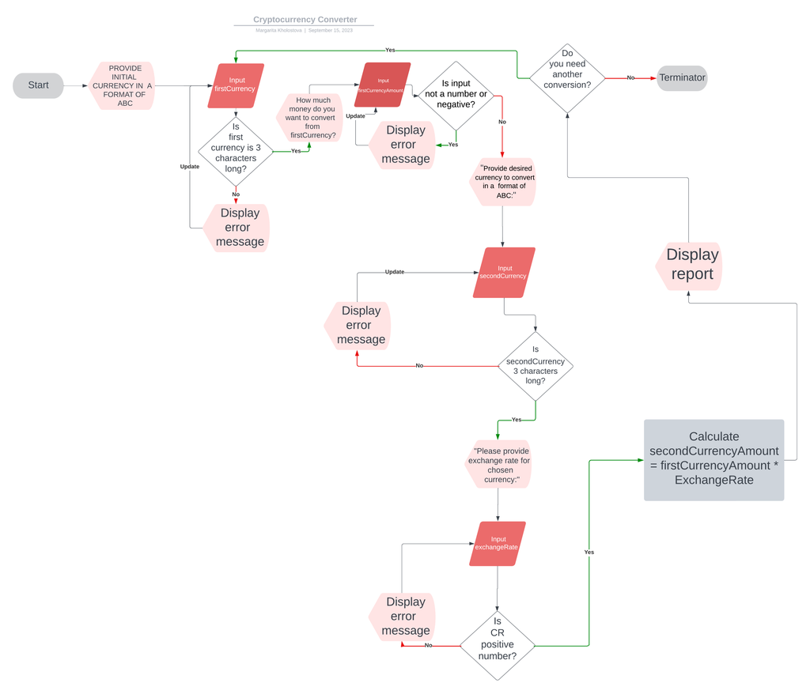

Figire 1. Flowchar describes the logic of Currency Conversion program.

```python
#checks if input follows format and not empty
def checkInputCurrency(currency):
    if currency and len(currency) == 3:
        return True
    else:
        print("Error: Wrong format or empty input!")
        return False

#gets the input of the initial currency
def getCurrencyInput(prompt_message):
    while True:
        currency = input(prompt_message).strip()

        if checkInputCurrency(currency):
            return currency

#checks money amount input for being empty and being positive
def getNumberInput(prompt_message):
    while True:
        amount_str = input(prompt_message).strip()
        #amount = float(amount_str)
        if amount_str:
            try:
                amount = float(amount_str)
                if amount > 0:
                    return amount
                elif amount <= 0:
                    print("Error: Negative number!")
            except ValueError:
                print("Error: Invalid input! Please enter a positive number.")
        else:
            print("Error: Empty input!")


#convert one currency into another and returns new amount, exchange rate
def currencyConversion(currencyAmount, secondCurrency):

    #in the future I would use API to get the rate rather then ask a user
    exchangeRate = getNumberInput("Please provide exchange rate for chosen currency: ")
    newAmount = currencyAmount * exchangeRate

    print("Conversion to "+secondCurrency+ " is complete!")

    return exchangeRate, newAmount

def printReport(initialCurrency, initialAmount, desiredCurrency,exchangeRate, newAmount):
    print("Conversion from " + initialCurrency.upper()  + " to " + desiredCurrency.upper()  + """ has been complete.
Initial balance of """ + str(initialAmount) + initialCurrency.upper() + " has been changed to " + str(newAmount) + desiredCurrency.upper()  +
         " at exhange rate = "+str(exchangeRate))
```

```python
while True:

    firstCurrency = getCurrencyInput("Provide initial currency in a format of ABC: ")

    firstCurrencyAmount = getNumberInput("How much money to you want to convert from " + firstCurrency +"?")

    secondCurrency= getCurrencyInput("Provide desired currency to convert in a format of ABC: ")

    usedExchangeRate, secondCurrencyAmount = currencyConversion(firstCurrencyAmount, secondCurrency)

    printReport(firstCurrency, firstCurrencyAmount, secondCurrency, usedExchangeRate, secondCurrencyAmount)


    repeat = input("Do you need another conversion? (yes/no): ").strip().lower()

    if repeat == 'no' or repeat == 'n':
        break
```

```
Provide initial currency in a format of ABC: btc
How much money to you want to convert from btc?25
Provide desired currency to convert in a format of ABC: eth
Please provide exchange rate for chosen currency: 0.05
Conversion to eth is complete!
Conversion from BTC to ETH has been complete.
Initial balance of 25.0BTC has been changed to 1.25ETH at exhange rate = 0.05
Do you need another conversion? (yes/no): n
```

# Conclusions

The provided program offers a user-centric approach to currency conversion, where users can specify initial and desired currencies, the amount to convert, and the exchange rate.

The program handles input validation, conversion calculations, and detailed reporting through well-defined functions, showcasing fundamental concepts from the weekly learnings, such as error handling and functional decomposition.

The accompanying flowchart breaks down the program's operations, describing each step from initial input to final report generation.

While the current iteration requires manual information for exchange rates, a noted future enhancement is integrating trusted sources for real-time rates, amplifying the program's efficiency and automation capabilities. Also in a future enhancement the manual input of currency code should be change for limited option to chose from the provided list.

# References

1. Guttag, J. V. (2021). Introduction to computation and programming using python, third edition: With application to computational modeling and Understanding Data. MIT Press.
2. Kalb, I. (2018). Learn to program with python 3: A step-by-step guide to programming. Apress.
3. OpenAI. (2023). ChatGPT based on GPT-4 architecture. OpenAI. https://www.openai.com/